# Práctica reconocimiento de emociones de la asignatura IPO del MUSI

# Análisis de un modelo de reconocimiento de emociones con la herramienta LIME

## Introducción

Se nos ha proporcionado una red neuronal entrenada con un conjunto de caras que expresan las 6 emociones básicas más la neutra.

Deseamos obtener una explicación de los elementos que componen las imágenes que nos permita saber en que se fija la red neuronal proporcionada para dirimir que emoción se está expresando. Es decir, queremos averigüar que partes de las caras son las que más contribuyen en cada probabilidad que calcula la red.

## Requisitos

Son necesarias las siguientes librerias y sus dependencias:

- keras
- lime
- abind
- magick
- lattice
- ggplot2
- gdata
- caret
- e1071
- pillow (`pip install pillow`)
- SciPy (`pip install SciPy`)

# Antecedentes: el experimento en clase

Durante una sesión práctica se encuestó a los alumnos para saber cuan buenos reconocedores de emociones son. En el siguiente apartado se muestra la matriz de confusión del resultado de la prueba.

## Matriz de confusión de las respuestas de la clase

```r
library(gdata)
# Importamos el fichero CSV
data = read.csv("../data/csv/Respuestas_emociones.csv", stringsAsFactors= FALSE)

# Muestra la estructura interna del objeto
str(data)
```

```
'data.frame':   880 obs. of  2 variables:
 $ actual   : chr  "Anger" "Anger" "Anger" "Anger" ...
 $ predicted: chr  "Anger" "Anger" "Fear" "Joy" ...
```

```r
# 'data.frame':880 obs. of  2 variables:
#  $ actual   : chr"Anger" "Anger" "Anger" "Anger" ...
#  $ predicted: chr"Anger" "Anger" "Fear" "Joy" ...

library(caret)
# creamos la matriz de confusión
confusionMatrix(
  # un factor de clases predichas
  data = as.factor(data$predicted),
  # un factor de clases que se utilizará como resultados verdaderos
  reference = as.factor(data$actual)
  )
```

```
Confusion Matrix and Statistics

          Reference
Prediction Anger Disgust Fear Joy Neutral Sadness Surprise
  Anger       61      22    4  10       7       5        5
  Disgust     15      69    5   7       0      27        0
  Fear         5       3   34   8       0      10       15
  Joy          3       0    4  60       3       2        0
  Neutral     27      14   29  16      97      26        0
  Sadness     13      24    8   4       2      61        0
  Surprise     8       0   48   5       1       1      112

Overall Statistics

               Accuracy : 0.5614
                 95% CI : (0.5279, 0.5945)
    No Information Rate : 0.15
    P-Value [Acc > NIR] : < 2.2e-16

                  Kappa : 0.4888

 Mcnemar's Test P-Value : NA

Statistics by Class:

                     Class: Anger Class: Disgust Class: Fear Class: Joy Class: Neutral Class: Sadness Class: Surprise
Sensitivity               0.46212        0.52273     0.25758    0.54545         0.8818        0.46212          0.8485
Specificity               0.92914        0.92781     0.94519    0.98442         0.8545        0.93182          0.9158
Pos Pred Value            0.53509        0.56098     0.45333    0.83333         0.4641        0.54464          0.6400
Neg Pred Value            0.90731        0.91678     0.87826    0.93812         0.9806        0.90755          0.9716
Prevalence                0.15000        0.15000     0.15000    0.12500         0.1250        0.15000          0.1500
Detection Rate            0.06932        0.07841     0.03864    0.06818         0.1102        0.06932          0.1273
Detection Prevalence      0.12955        0.13977     0.08523    0.08182         0.2375        0.12727          0.1989
Balanced Accuracy         0.69563        0.72527     0.60138    0.76494         0.8682        0.69697          0.8821
```

## Conclusiones del resultado de la encuesta en clase

La precisión arrojada es aproximadamente un 56%, creemos que esta precisión tan baja puede ser debida a la falta de contexto, pues se trata de imágenes no animadas y sin mayor información que la puramente gráfica.

# Pruebas LIME con la red neuronal

En los siguientes apartados vamos a experimentar con la red neuronal suministrada. De las dos opciones que se nos han ofrecido, hemos decidido usar la entrenada con las *caras recortadas* por arrojar una precisión un poco mejor que la original.

## Metodología

Suministraremos a la red entrenada una selección de caras del conjunto de pruebas que expresarán algunas emociones de nuestro interés. Por cada una de las caras suministradas, la red generará un conjunto de probabilidades correspondientes a cada una de las posibles emociones.

En cada caso, se usará la herramienta LIME (Local Interpretable Model-Agnostic Explanations) para conseguir el conjunto de explicaciones que se consideren más ilustrativas. Comentaremos los resultados obtenidos, destacando lo singular por encima de lo esperado.

## Carga de la red neuronal

Vamos a cargar el modelo de red neuronal ya entrenado con el *dataset* de caras recortadas.

```r
library(keras)

# Trayectoria de la serialización del modelo
model_path = "../data/model/model7Emociones.h5"
# Carga del modelo HDF5
model <- load_model_hdf5(
  model_path,
  custom_objects= NULL,
  compile = TRUE
  )
```

[output not shown]

## Preparación de las caras

```r
# Trayectoria del conjunto de imágenes de test
images_path = "../data/test_crop/"

# Preparaciónde las imágenes: Imágenes normalizadas en escala de grises de tamaño 128x128
## Genera lotes de imágenes con data aumentation en tiempo real
datagen <- image_data_generator(rescale= 1/255 # Normalización de las imágenes entre 0 y 1
                                )
## Genera lotes de imágenes a partir de un directorio
test_generator <- flow_images_from_directory(
  directory = images_path, # Debe contener un subdirectorio por clase
  generator = datagen,
  color_mode = "grayscale", # Las imágenes se convertirán para tener 1 canal de color
  target_size = c(128, 128), # Las imágenes se redimensionarán a 128 x 128
  class_mode= "categorical", # 2D one-hot encoded labels
  batch_size=1, # Lotes formados por 1 imagen
  shuffle= FALSE # Sin aleatorización
  )
```

```
Found 132 images belonging to 7 classes.
```

## Evaluación de las predicciones

```r
# Realización de las predicciones
## Generación de predicciones a partir de un generador de datos
STEP_SIZE =
  test_generator$n/test_generator$batch_size
prediction <- model %>% predict_generator(
  # Generador que produce lotes de imágenes
  generator = test_generator,
  # Número total de pasos (lotes de imágenes) a proporcionar por el generador antes de detenerse
  steps = STEP_SIZE)
```

```
2021-06-05 12:47:05.017991: I tensorflow/compiler/mlir/mlir_graph_optimization_pass.cc:176] None of the MLIR Optimization Passes are enabled (registered 2)
2021-06-05 12:47:05.036402: I tensorflow/core/platform/profile_utils/cpu_utils.cc:114] CPU Frequency: 2899885000 Hz
```

```r
head(prediction)
```

```
          [,1]         [,2]         [,3]         [,4]         [,5]         [,6]         [,7]
[1,] 0.9732536 1.486878e-05 2.031849e-05 1.048117e-04 2.640544e-02 2.002597e-04 8.594183e-07
[2,] 0.9712657 4.825610e-07 2.140396e-05 1.420997e-04 2.716509e-02 1.404623e-03 6.865957e-07
[3,] 0.9995404 1.227113e-05 1.644911e-08 2.000600e-04 2.438742e-04 2.089900e-07 3.143650e-06
[4,] 0.9826591 7.536783e-08 6.509033e-06 2.541134e-08 9.518804e-06 3.288751e-06 1.732141e-02
[5,] 0.9409639 3.319219e-08 5.603477e-02 1.709934e-06 2.710622e-03 2.889431e-04 4.443893e-08
[6,] 0.9346032 1.730108e-06 9.230022e-07 2.439824e-04 6.511680e-02 3.332497e-05 4.477892e-08
```

```r
labels <- unlist(test_generator$class_indices)
print(labels)
```

```
   ANGER  DISGUST     FEAR      JOY  NEUTRAL  SADNESS SURPRISE
       0        1        2        3        4        5        6
```

## Preparativos LIME

```r
library(lime)
library(abind)

# Necesitamos pasa a LIME un ítem cualquiera del mismo tipo de los que le pediremos explicaciones.
# En nuestro caso le pasamos una imágen del conjunto de test
sample_path = '../data/test_crop/ANGER/Alicia_EnragedCompressedLips.png'

# Definimos la función que vamos a utilizar para preparar las imágenes para el modelo.

# Transforma un vector de caracteres al formato que espera el modelo (imágenes normalizadas en escala de grises de tamaño 128x128): para cada imagen creamos un array unidimensional en row-major order con el número de canales al final y lo normalizamos entre 0 y 1
img_preprocess <- function(x) {
  arrays <- lapply(x, function(path) {
    img <- image_load(path, grayscale=TRUE, target_size = c(128, 128))
    x <- image_to_array(img, data_format = "channels_last")
    x <- array_reshape(x, c(1, dim(x)))
    x <- x/255.0
    }
    )
  do.call(abind, c(arrays, list(along = 1)))
}

# Creamos un explicador con LIME a partir de nuestro modelo y con nuestras etiquetas
explainer <- lime(
  x = sample_path,
  model = as_classifier(model, labels = names(labels)),
  preprocess = img_preprocess
  )
```

### Cara número 1: alegría

Vamos a analizar una imágen con la etiqueta alegría

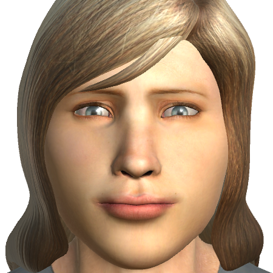

Wanda, alegre ma non troppo

```r
explain_img_path = '../data/test_crop/JOY/Wanda_IngratiatingSmile.png'

res <- predict(model, img_preprocess(explain_img_path))
colnames(res) <- names(labels)
print(res)
```

```
            ANGER     DISGUST         FEAR       JOY     NEUTRAL     SADNESS     SURPRISE
[1,] 1.062606e-08 0.000476656 1.607817e-10 0.9956175 0.003896179 9.74334e-06 1.226902e-16
```

[figure not shown]

```r
library(magick)
n_superpixels = 20

# Mostraremos los superpixels para poder evaluar cuáles son las zonas que se utilizan antes de aplicar la función de explicación.
# Un superpixel és cada una de las zonas en las que se segmenta la imagen para facilitar las explicaciones en los modelos que utilizan imágenes.
# Estos superpíxeles deberían contener patrones específicos de la imagen, por ello visualizarlos nos puede dar una idea de las zonas que se utilizan para la explicación.
# Tenemos que tener en cuenta que si las características importantes de la imagen se cortan en demasiados segmentos podemos obtener un modelo incorrecto para la explicación.
# Cuanto más grande sea el objeto que buscamos en relación al tamaño de la imagen, menos superpíxeles debería haber.
plot_superpixels(explain_img_path, n_superpixels)
```

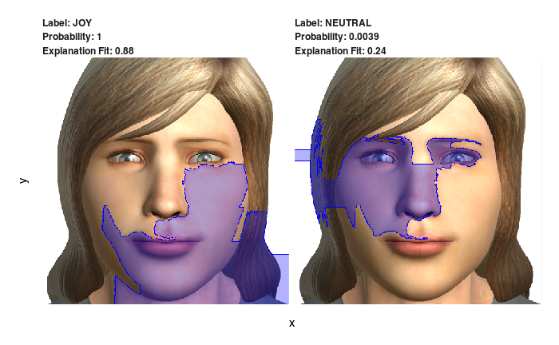

```r
# Generación de la explicación
explanation <- explain(
  explain_img_path,
  explainer,
  n_labels = 2,
  n_features = n_superpixels %/% 2, # limitamos el cardinal del conjunto de features para la explicación a la mitad de superpíxeles
  n_superpixels = n_superpixels)
# Visualización de los resultados
plot_image_explanation(as.data.frame(explanation))
```

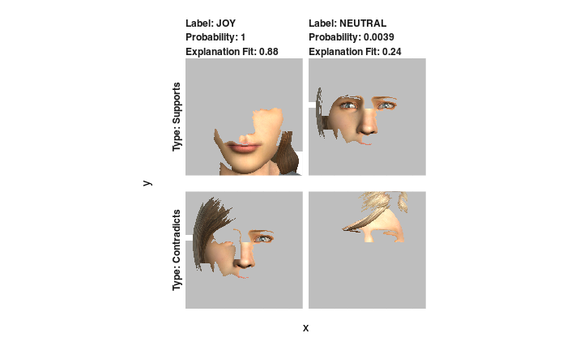

```r
plot_image_explanation(as.data.frame(explanation),
                       display = 'block',
                       show_negative = TRUE)
```

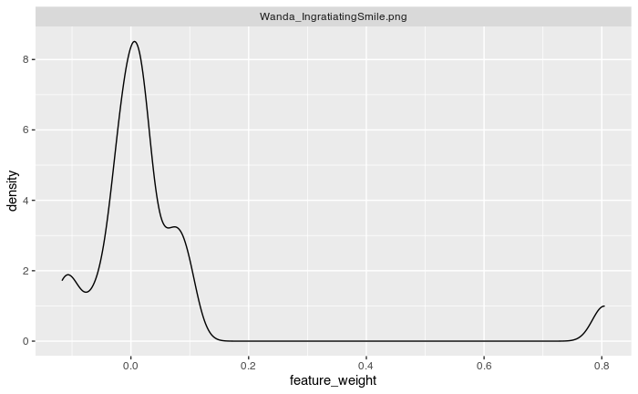

```r
# Se puede precisar un poco más mostrando la gráfica de los pesos de las características para establecer un umbral (threshold) adecuado:
library(ggplot2)
explanation %>%
  ggplot(aes(x = feature_weight)) +
  facet_wrap(~ case, scales = "free") +
  geom_density()
```

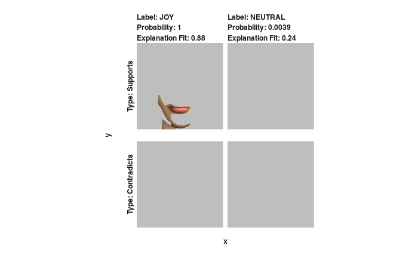

```r
plot_image_explanation(as.data.frame(explanation),
                       display = 'block',
                       show_negative = TRUE,
                       threshold = 0.20)
```